# Managing Salmon for Wildlife

12/6/2021

## Context

-Why Manage Salmon for wildlife? They are a Keystone species and they provide much needed Biomass for Bears.

-Whats the problem? Humans impact Bear habitat.(waterways, wetlands)

-Why important Manage Salmon for wildlife help maintain natures food web. Which is a network of complex interactions formed by the feeding relationships in various organisms in an ecosystem.

## Alaskan Bear

[figure not shown]

image Gettyimage

## Concept

- Does managing fisheries for wildlife limit salmon consumption by bears in Alaska?
- Comparing Graph process it into population
- Include visual images
- Findings

## Library package

- dplyr
- ggplot2

## knitr opts

knitr

## Data Varibles

Site (A creek, C Creek, Hansen Creek, Pedro Ponds, Alaska)

Year(1997-2018)

Biomass Consumed

Biomass Available

Average Percentage Eaten

Bear estimate

## Data

```
##            Site Year Biomass.Consumed..kg. Biomass.Available..kg.
## 1  Hansen Creek 1997               4732.86               21672.01
## 2  Hansen Creek 1998               6965.65               31704.24
## 3  Hansen Creek 1999               6201.39               41331.14
## 4  Hansen Creek 2000               2445.15               10255.53
## 5  Hansen Creek 2001               1420.59                6212.46
## 6  Hansen Creek 2002               6151.34               21074.74
## 7  Hansen Creek 2003               4310.24               26653.24
## 8  Hansen Creek 2004               2251.86                8866.30
## 9  Hansen Creek 2005               1262.82                8973.26
## 10 Hansen Creek 2006               5584.17               47897.93
## 11 Hansen Creek 2007               4053.14               18390.22
## 12 Hansen Creek 2008               2143.73                9523.70
## 13 Hansen Creek 2009               1657.98                3563.79
## 14 Hansen Creek 2010               7276.75               30378.74
```

[output cut: 133 more lines]

## Summary data

```
##      Site                Year      Biomass.Consumed..kg. Biomass.Available..kg.
##  Length:73          Min.   :1997   Min.   :    1.28      Min.   :   19.52
##  Class :character   1st Qu.:2005   1st Qu.:  151.96      1st Qu.:  686.38
##  Mode  :character   Median :2009   Median :  462.60      Median : 1808.49
##                     Mean   :2009   Mean   : 1848.82      Mean   : 8096.54
##                     3rd Qu.:2014   3rd Qu.: 2738.29      3rd Qu.:10499.28
##                     Max.   :2018   Max.   :10925.34      Max.   :47897.93
##
##  Average.Percentage.Eaten Bear.Estimate
##  Length:73                Min.   : 3.16
##  Class :character         1st Qu.:14.03
##  Mode  :character         Median :23.98
##                           Mean   :21.47
##                           3rd Qu.:31.42
##                           Max.   :34.76
##                           NA's   :69
```

## Box Plot Year, Biomass Comsumed

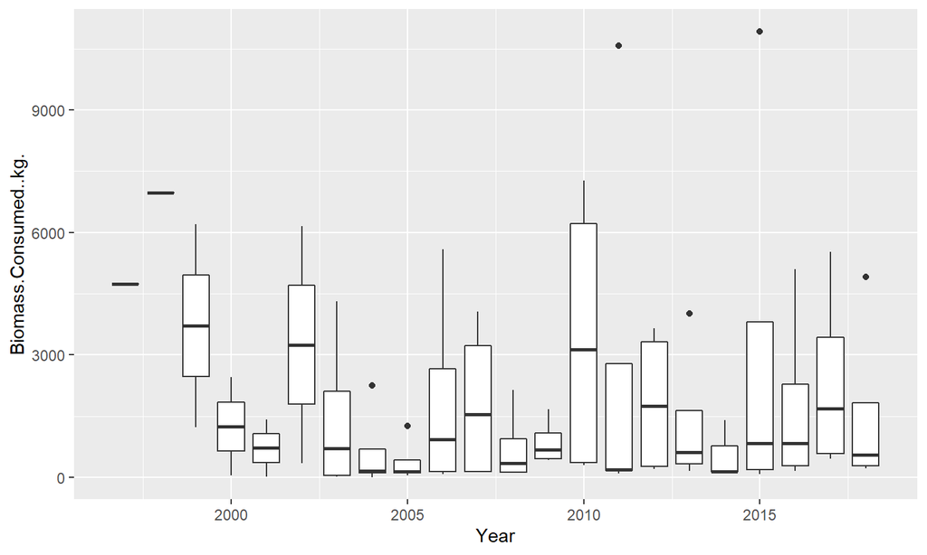

## Box Plot Year, Biomass Available

1997 show large amount of biomass available

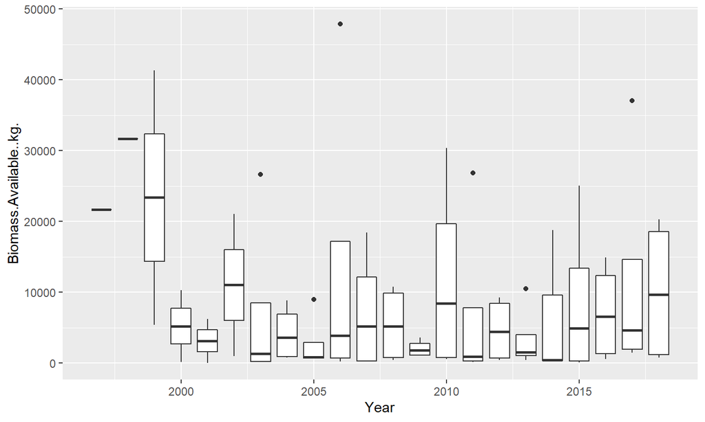

## Plots Average Percentage Eaten

2011 highest percent eaten at (A creek) looking at the color site.

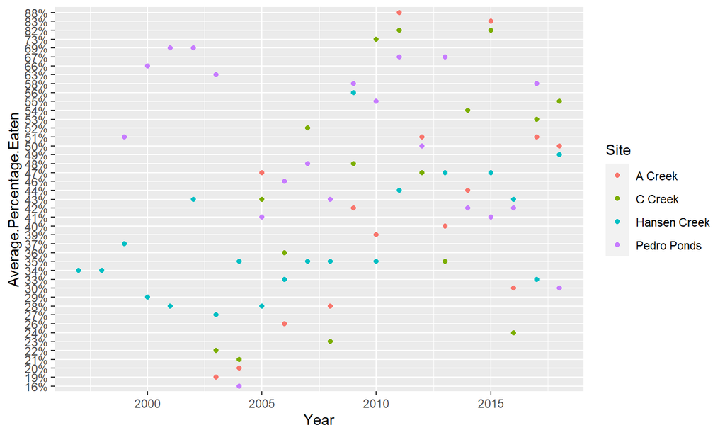

## Pipe filter Biomass Consumed mean

Description of Biomass consumed and mean for each variable

```
##            Site Year Biomass.Consumed..kg. Biomass.Available..kg.
## 1  Hansen Creek 1997               4732.86               21672.01
## 2  Hansen Creek 1998               6965.65               31704.24
## 3  Hansen Creek 1999               6201.39               41331.14
## 4  Hansen Creek 2000               2445.15               10255.53
## 5  Hansen Creek 2002               6151.34               21074.74
## 6  Hansen Creek 2003               4310.24               26653.24
## 7  Hansen Creek 2004               2251.86                8866.30
## 8  Hansen Creek 2006               5584.17               47897.93
## 9  Hansen Creek 2007               4053.14               18390.22
## 10 Hansen Creek 2008               2143.73                9523.70
## 11 Hansen Creek 2010               7276.75               30378.74
## 12 Hansen Creek 2011              10569.78               26809.49
## 13 Hansen Creek 2012               3649.02                8132.24
## 14 Hansen Creek 2013               4003.84               10499.28
```

[output cut: 31 more lines]

## Scale point size, color, alpha

Scale able make changes with size and color(red), alpha,

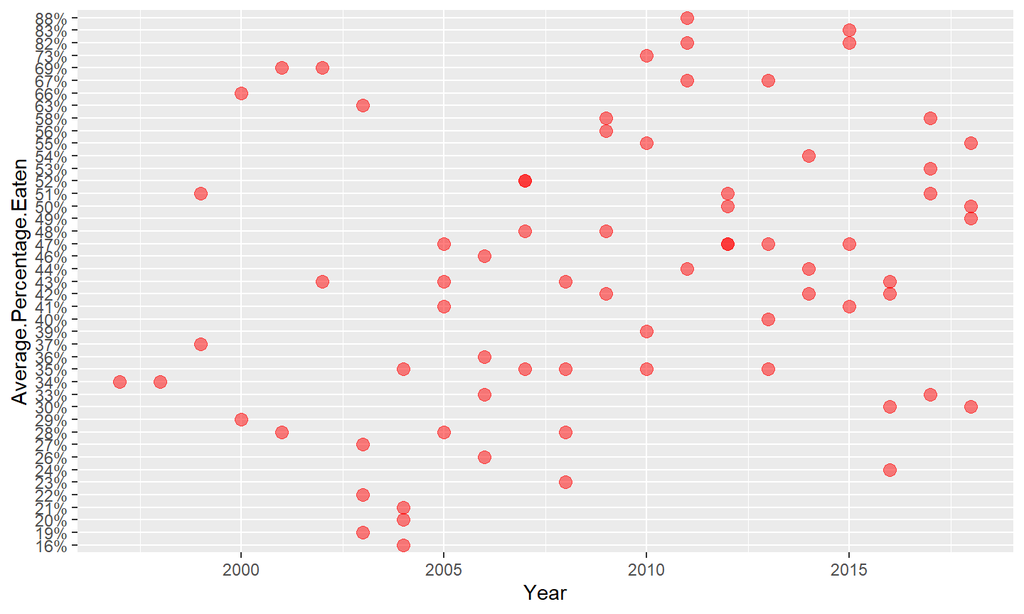

## Scale log scatter plot

Able scale log scatter plot, change size color(blue), alpha

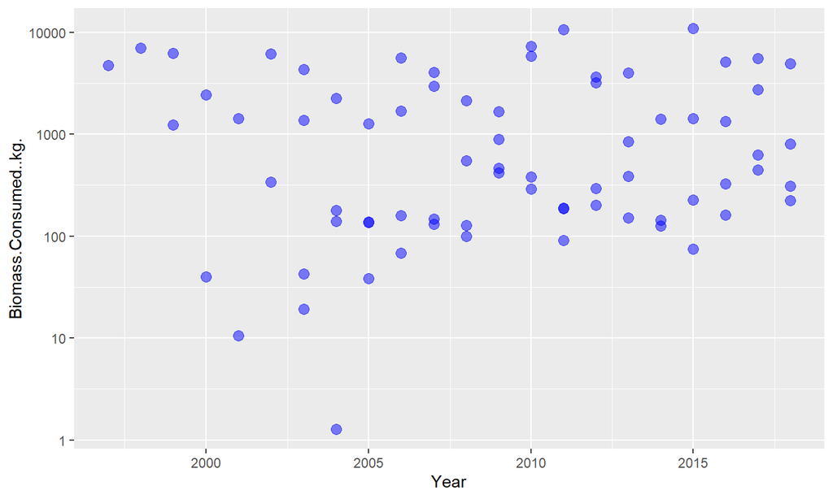

## facet wrap scale log scatter plot

Facet wrap scale log scatter plot showing separate year for biomass consumed and biomass available

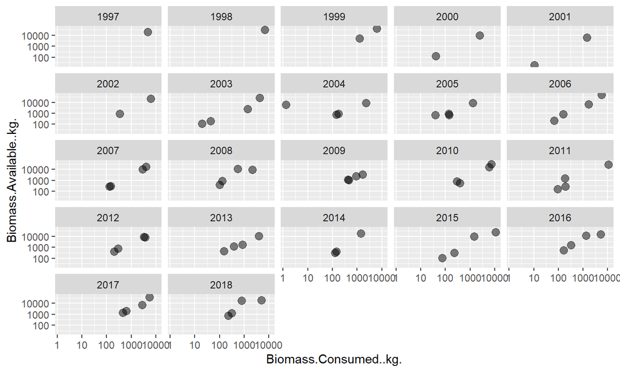

## Scatter plot Year, Biomass Comsumed

2011-2015 large amount of biomass consumed Hansen Creek

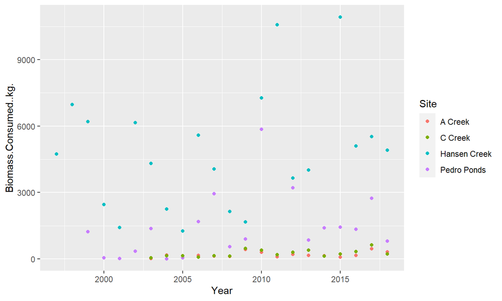

## Scatter plot Year, Biomass Available

2006 show that Hansen Creek has the most abundant biomass

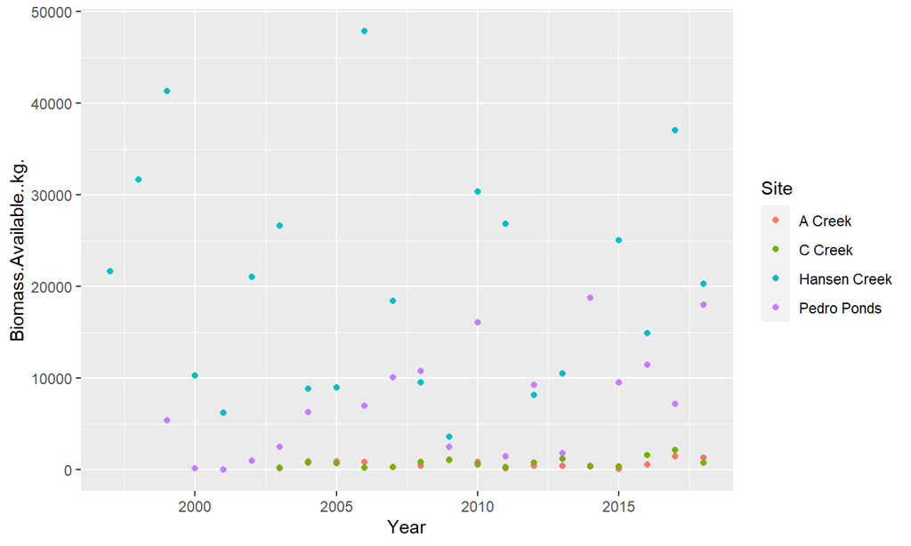

## Scatter plot Biomass Available, Biomass Comsumed

Scatter plot Biomass Available, Biomass Comsumed at each site

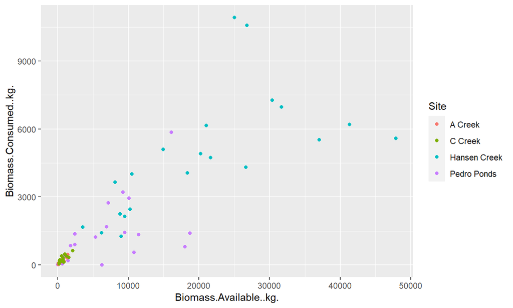

## Biomass Available histogram

Count of biomass available add # bins

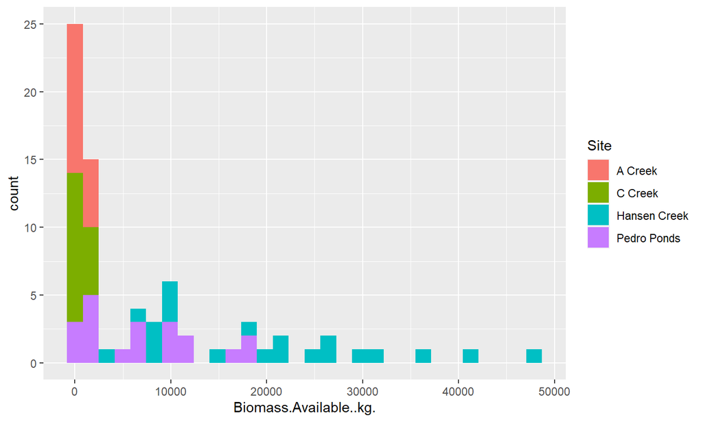

## Biomass Comsumed histogram

Count of biomass consumed and added # bin

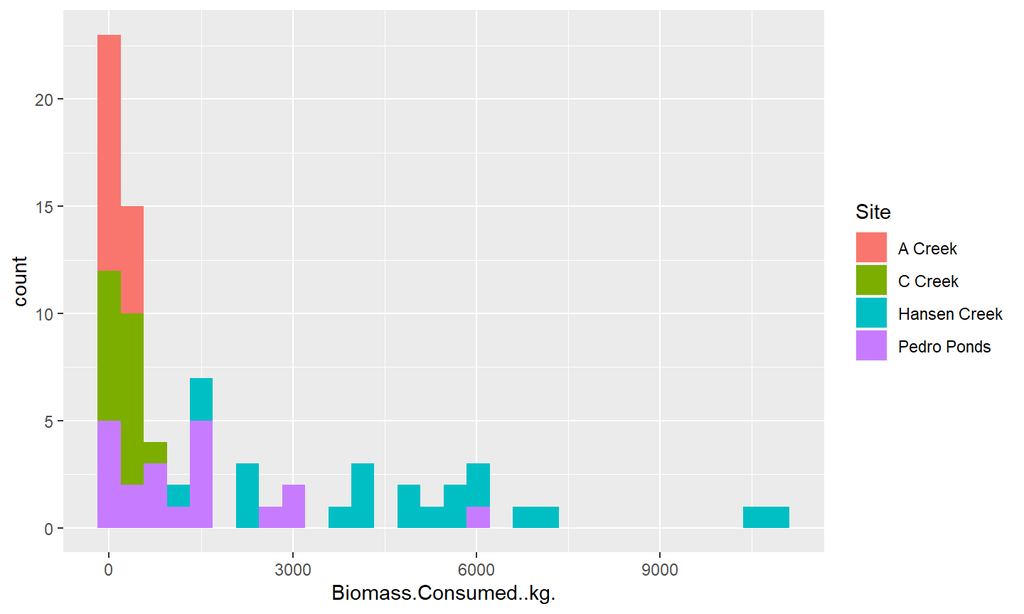

## Time line series Biomass Available

Pipe plot of Year, Biomass available also add color

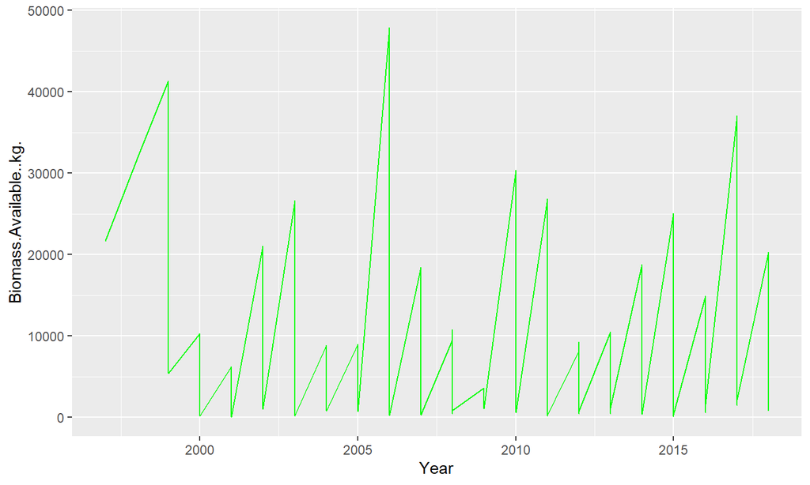

## Time line series Biomass Consumed

Pipe plot of Year, Biomass consumed also add color

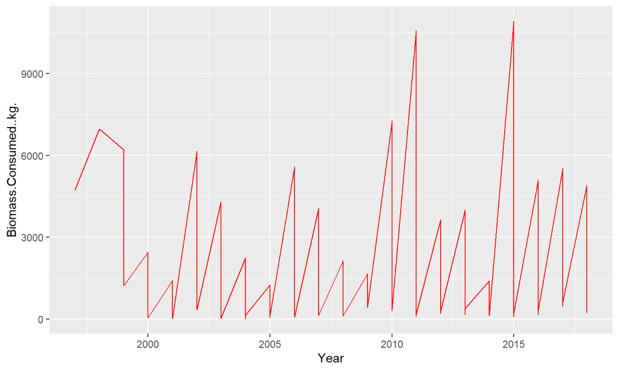

## Copper River Sockeye

[figure not shown]

image alaskatourjobs

## Citation

Lincoln, A., Hilborn, R., Wirsing, A. J., & Quinn, T. P.. (2019). Managing salmon for wildlife: do fisheries limit salmon consumption by bears in small Alaskan streams? (Version 1). figshare. https://doi.org/10.6084/m9.figshare.10315925.v1 ([])